# Reporte Hito 1

### Dendograma

```python
df_sample = df_datos.sample(n=1000, random_state=1)

complete = linkage(df_sample, method="complete")
single = linkage(df_sample, method="single")
average = linkage(df_sample, method="average")
ward = linkage(df_sample, method="ward")
```

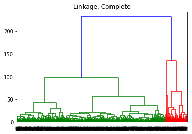

```python
# Visualización
dendrogram(complete)
plt.title("Linkage: Complete")
plt.show()
```

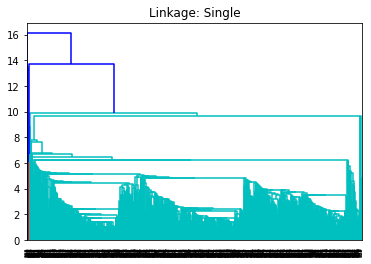

```python
# Visualización
dendrogram(single)
plt.title("Linkage: Single")
plt.show()
```

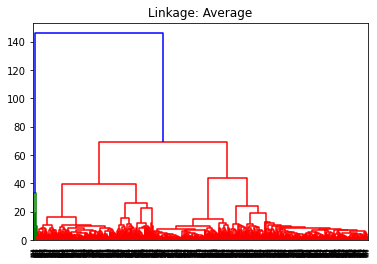

```python
# Visualización
dendrogram(average)
plt.title("Linkage: Average")
plt.show()
```

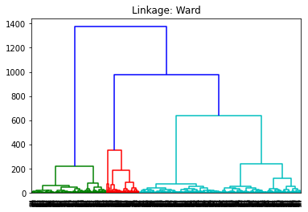

```python
# Visualización
dendrogram(ward)
plt.title("Linkage: Ward")
plt.show()
```

```python
# Clustering aglomerativo
complete = AgglomerativeClustering(n_clusters=None, linkage="complete", distance_threshold=75).fit(df_sample)
ward = AgglomerativeClustering(n_clusters=None, linkage="ward", distance_threshold=250).fit(df_sample)
```

```python
new_X_sample = PCA(n_components=2, random_state=0).fit_transform(df_sample)
```

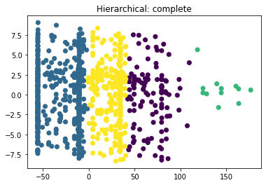

```python
plt.scatter(new_X_sample[:, 0], new_X_sample[:, 1], c=complete.labels_)
plt.title("Hierarchical: complete")
plt.show()
```

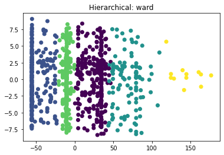

```python
plt.scatter(new_X_sample[:, 0], new_X_sample[:, 1], c=ward.labels_)
plt.title("Hierarchical: ward")
plt.show()
```

### K-means

[figure not shown]

```python
sse = []

clusters = list(range(1, 10))
for k in clusters:
    kmeans = KMeans(n_clusters=k).fit(df_datos)
    sse.append(kmeans.inertia_)

plt.plot(clusters, sse, marker="o")
plt.title("Metodo del codo de 1 a 10 clusters")
plt.grid(True)
plt.show()
```

```python
kmeans = KMeans(n_init=20,n_clusters=4).fit(df_datos)
kmeans.labels_
```

```
array([3, 0, 0, ..., 3, 3, 3], dtype=int32)
```

```python
new_X = PCA(n_components=2, random_state=0).fit_transform(df_datos)
```

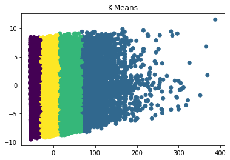

```python
# Respuesta
plt.scatter(new_X[:, 0], new_X[:, 1], c=kmeans.labels_)
plt.title("K-Means")
plt.show()
```

### Dbscan

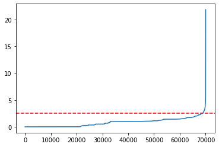

```python
# Encontrando un valor apto para `eps`

nbrs = NearestNeighbors(n_neighbors=3).fit(df_datos)
distances, indices = nbrs.kneighbors(df_datos)

distances = np.sort(distances, axis=0)
distances = distances[:,1]
plt.axhline(y=2.5, color='r', linestyle='--')
plt.plot(distances)
```

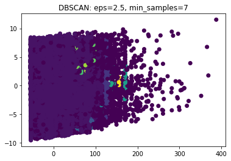

```python
# Generacióñ del modelo
eps = 2.5
min_samples = 7
dbscan = DBSCAN(eps=eps, min_samples=min_samples).fit(df_datos)

# Graficacin del os resultados
new_X = PCA(n_components=2, random_state=0).fit_transform(df_datos)
plt.scatter(new_X[:,0], new_X[:,1], c=dbscan.labels_)
plt.title(f"DBSCAN: eps={eps}, min_samples={min_samples}")
plt.show()
```

### Interpretación y comparación

```python
print("Silhouette Score K-Means k=4\t", silhouette_score(df_datos, kmeans.labels_))
print("Silhouette Score Clustering Aglomerativo Complete k=4\t", silhouette_score(df_sample, complete.labels_))
print("Silhouette Score Clustering Aglomerativo Ward k=5\t", silhouette_score(df_sample, ward.labels_))
_filter_label = dbscan.labels_ >= 0
print("Silhouette Score DBSCAN\t", silhouette_score(df_datos[_filter_label], dbscan.labels_[_filter_label]))
```

```
Silhouette Score K-Means k=4	 0.653977614422811
Silhouette Score Clustering Aglomerativo Complete k=4	 0.509145719687191
Silhouette Score Clustering Aglomerativo Ward k=5	 0.5878251624281534
Silhouette Score DBSCAN	 -0.6425620262328772
```

Viendo los graficos, y el silhouette score, es claro que el mejor modelo es el K-Means con k=4.

No se pudo hacer interactivo, entonces se hará con estadísticas de resumen de cada cluster.

```python
df_datos['kmeans_labels'] = kmeans.labels_
```

```python
df_datos[df_datos['kmeans_labels'] == 1].describe()
```

|  | numper | region | ytoth | o10 | educ | s12 | s13 | kmeans_labels |
| --- | --- | --- | --- | --- | --- | --- | --- | --- |
| count | 5125.000000 | 5125.000000 | 5125.000000 | 5125.000000 | 5125.000000 | 5125.000000 | 5125.000000 | 5125.0 |
| mean | 4.824390 | 6.938732 | 0.017890 | 155.472000 | 7.629463 | 2.519805 | 5.884224 | 1.0 |
| std | 1.763536 | 3.786422 | 0.026200 | 34.481815 | 2.679007 | 1.777606 | 0.776561 | 0.0 |
| min | 2.000000 | 0.000000 | 0.000000 | 123.000000 | 1.000000 | 1.000000 | 1.000000 | 1.0 |
| 25% | 4.000000 | 5.000000 | 0.008137 | 135.000000 | 5.000000 | 1.000000 | 5.500000 | 1.0 |
| 50% | 5.000000 | 6.000000 | 0.012785 | 140.000000 | 8.000000 | 2.000000 | 6.000000 | 1.0 |
| 75% | 6.000000 | 10.000000 | 0.020494 | 169.000000 | 11.000000 | 3.000000 | 6.444444 | 1.0 |
| max | 19.000000 | 15.000000 | 1.000000 | 442.000000 | 12.000000 | 9.000000 | 7.000000 | 1.0 |

```python
df_datos[df_datos['kmeans_labels'] == 0].describe()
```

|  | numper | region | ytoth | o10 | educ | s12 | s13 | kmeans_labels |
| --- | --- | --- | --- | --- | --- | --- | --- | --- |
| count | 18427.000000 | 18427.000000 | 18427.000000 | 18427.000000 | 18427.000000 | 18427.000000 | 18427.000000 | 18427.0 |
| mean | 2.186900 | 7.610246 | 0.002511 | 3.093884 | 4.535030 | 2.344060 | 5.206096 | 0.0 |
| std | 1.224021 | 3.719813 | 0.003266 | 6.670021 | 3.311222 | 1.813044 | 1.219914 | 0.0 |
| min | 1.000000 | 0.000000 | 0.000000 | 0.000000 | 0.000000 | 1.000000 | 1.000000 | 0.0 |
| 25% | 1.000000 | 5.000000 | 0.000842 | 0.000000 | 2.000000 | 1.000000 | 4.500000 | 0.0 |
| 50% | 2.000000 | 7.000000 | 0.001682 | 0.000000 | 4.000000 | 2.000000 | 5.000000 | 0.0 |
| 75% | 3.000000 | 10.000000 | 0.003009 | 0.000000 | 6.000000 | 2.000000 | 6.000000 | 0.0 |
| max | 12.000000 | 15.000000 | 0.135375 | 24.000000 | 12.000000 | 9.000000 | 7.000000 | 0.0 |

```python
df_datos[df_datos['kmeans_labels'] == 3].describe()
```

|  | numper | region | ytoth | o10 | educ | s12 | s13 | kmeans_labels |
| --- | --- | --- | --- | --- | --- | --- | --- | --- |
| count | 28425.000000 | 28425.000000 | 28425.000000 | 28425.000000 | 28425.000000 | 28425.000000 | 28425.000000 | 28425.0 |
| mean | 2.943325 | 7.512260 | 0.005404 | 45.943993 | 6.333052 | 2.702762 | 5.738093 | 3.0 |
| std | 1.409300 | 3.800692 | 0.007924 | 7.754326 | 3.128813 | 1.999504 | 0.962405 | 0.0 |
| min | 1.000000 | 0.000000 | 0.000000 | 25.000000 | 0.000000 | 1.000000 | 1.000000 | 3.0 |
| 25% | 2.000000 | 5.000000 | 0.002091 | 45.000000 | 5.000000 | 1.000000 | 5.000000 | 3.0 |
| 50% | 3.000000 | 7.000000 | 0.003658 | 45.000000 | 6.000000 | 2.000000 | 6.000000 | 3.0 |
| 75% | 4.000000 | 10.000000 | 0.006286 | 48.000000 | 9.000000 | 4.000000 | 6.500000 | 3.0 |
| max | 15.000000 | 15.000000 | 0.513511 | 68.000000 | 12.000000 | 9.000000 | 7.000000 | 3.0 |

```python
df_datos[df_datos['kmeans_labels'] == 2].describe()
```

|  | numper | region | ytoth | o10 | educ | s12 | s13 | kmeans_labels |
| --- | --- | --- | --- | --- | --- | --- | --- | --- |
| count | 18049.000000 | 18049.000000 | 18049.000000 | 18049.000000 | 18049.000000 | 18049.000000 | 18049.000000 | 18049.0 |
| mean | 3.623026 | 7.373927 | 0.010615 | 90.292260 | 7.441797 | 2.920716 | 5.847333 | 2.0 |
| std | 1.375424 | 3.832885 | 0.012825 | 11.559928 | 2.936449 | 2.029693 | 0.850448 | 0.0 |
| min | 1.000000 | 0.000000 | 0.000000 | 68.000000 | 0.000000 | 1.000000 | 1.000000 | 2.0 |
| 25% | 3.000000 | 5.000000 | 0.004477 | 84.000000 | 5.000000 | 1.000000 | 5.333333 | 2.0 |
| 50% | 3.000000 | 6.000000 | 0.007435 | 90.000000 | 8.000000 | 2.000000 | 6.000000 | 2.0 |
| 75% | 4.000000 | 10.000000 | 0.012217 | 94.000000 | 11.000000 | 4.000000 | 6.500000 | 2.0 |
| max | 12.000000 | 15.000000 | 0.480785 | 122.000000 | 12.000000 | 9.000000 | 7.000000 | 2.0 |

## Pregunta 4

```python
from sklearn import preprocessing
```

```python
df2013['ytoth'] = df2013['ytotcorh']

def filtrar_ingresos(data: pd.DataFrame, columns) -> pd.DataFrame:
  """ Filtra las columnas relevantes al analisis de ingresos"""
  new_data_frame = data[columns]
  new_data_frame = new_data_frame.groupby(['folio']).first().reset_index()
  new_data_frame.reset_index(drop=True, inplace=True)

  # Chequeo de que se hizo bien la agrupación
  folio_count = data['folio'].nunique()
  new_data_row_count = len(new_data_frame)
  assert folio_count == new_data_row_count

  return new_data_frame
```

```python
COLUMNAS_INGRESOS = ['sexo','edad','ytoth', 'region', 'comuna', 'zona', 'año','e6a','educ','o15','pco2','folio']

df_ingresos_2013 = filtrar_ingresos(df2013, COLUMNAS_INGRESOS)
df_ingresos_2013.name = "Casen 2013 Ingresos"

df_ingresos_2015 = filtrar_ingresos(df2015, COLUMNAS_INGRESOS)
df_ingresos_2015.name = "Casen 2015 Ingresos"

df_ingresos_2017 = filtrar_ingresos(df2017, COLUMNAS_INGRESOS)
df_ingresos_2017.name = "Casen 2017 Ingresos"

df_ingresos_2020 = filtrar_ingresos(df2020, COLUMNAS_INGRESOS)
df_ingresos_2020.name = "Casen 2020 Ingresos"

df_ingresos_2013["año"] = 2013
df_ingresos_2015["año"] = 2015
df_ingresos_2017["año"] = 2017
df_ingresos_2020["año"] = 2020

data_frames_ingresos = [df_ingresos_2020, df_ingresos_2017, df_ingresos_2015, df_ingresos_2013]

df_folio = pd.concat(data_frames_ingresos, ignore_index=True)
```

```python
print("Tamaño folio", str(df_folio.size))
X=df_folio.dropna()
X['decil'] = pd.qcut(df['ytoth'], 10,
                            labels = False)
X=X.drop(columns=['ytoth'])
X=X.dropna()
print("Tamañno variable",X.size)
X.head()
```

```
Tamaño folio 3413652
Tamañno variable 1734972
```

|  | folio | sexo | edad | region | comuna | zona | año | e6a | educ | o15 | pco2 | decil |
| --- | --- | --- | --- | --- | --- | --- | --- | --- | --- | --- | --- | --- |
| 0 | 1.101100e+11 | 2.0 | 34.0 | 1.0 | 1101.0 | 1.0 | 2020 | 9.0 | 5.0 | 2.0 | 1.0 | 2.0 |
| 1 | 1.101100e+11 | 2.0 | 5.0 | 1.0 | 1101.0 | 1.0 | 2020 | 7.0 | 1.0 | 5.0 | 5.0 | 2.0 |
| 2 | 1.101100e+11 | 1.0 | 57.0 | 1.0 | 1101.0 | 1.0 | 2020 | 13.0 | 8.0 | 8.0 | 2.0 | 6.0 |
| 4 | 1.101100e+11 | 1.0 | 11.0 | 1.0 | 1101.0 | 1.0 | 2020 | 7.0 | 1.0 | 5.0 | 5.0 | 6.0 |
| 5 | 1.101100e+11 | 1.0 | 55.0 | 1.0 | 1101.0 | 1.0 | 2020 | 9.0 | 5.0 | 2.0 | 1.0 | 9.0 |

### K-means

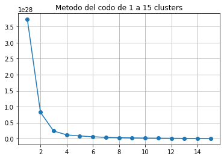

```python
sse = []

clusters = list(range(1, 16))
for k in clusters:
    kmeans = KMeans(n_clusters=k).fit(X)
    sse.append(kmeans.inertia_)

plt.plot(clusters, sse, marker="o")
plt.title("Metodo del codo de 1 a 15 clusters")
plt.grid(True)
plt.show()
```

Se observa que el número óptimo de clusters es 2 o 3

```python
from sklearn.metrics import silhouette_score
kmeans2 = KMeans(n_clusters=2, random_state=21).fit(X)
kmeans3 = KMeans(n_clusters=3, random_state=21).fit(X)
print("K-Means 2\t", silhouette_score(X, kmeans2.labels_))
print("K-Means 3\t", silhouette_score(X, kmeans3.labels_))
```

```
K-Means 2	 0.6598244668799502
K-Means 3	 0.7256869046873557
```

### Clustering Jerárquico Aglomerativo

```python
X = X.sample(frac=0.1, replace=False, random_state=1)
```

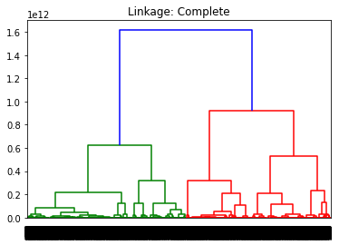

```python
complete = linkage(X, method="complete")
dendrogram(complete)
plt.title("Linkage: Complete")
plt.show()
```

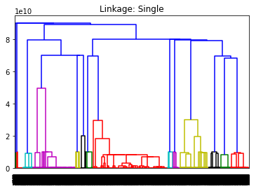

```python
single = linkage(X, method="single")
dendrogram(single)
plt.title("Linkage: Single")
plt.show()
```

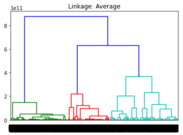

```python
average = linkage(X, method="average")
dendrogram(average)
plt.title("Linkage: Average")
plt.show()
```

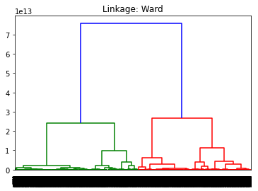

```python
ward = linkage(X, method="ward")
dendrogram(ward)
plt.title("Linkage: Ward")
plt.show()
```

Se escoge ward con 3 clusters

```python
X0 = X.sample(frac=0.2, replace=False, random_state=1)
ward_3 = AgglomerativeClustering(n_clusters=3, linkage="ward").fit(X0)
```

```python
from sklearn.metrics import silhouette_score
print("Clustering jerárquico aglomerativo 3 clusters\t", silhouette_score(X0, ward_3.labels_))
```

```
Clustering jerárquico aglomerativo 3 clusters	 0.6568935174705548
```

### Gráficos

```python
from sklearn.cluster import KMeans
kmeans3 = KMeans(n_clusters=3, random_state=20).fit(X)
df = X

df['grupo'] = kmeans3.labels_
df['grupo'].value_counts()
```

[output not shown]

```python
df.head()
```

|  | folio | sexo | edad | region | comuna | zona | año | e6a | educ | o15 | pco2 | decil | grupo |
| --- | --- | --- | --- | --- | --- | --- | --- | --- | --- | --- | --- | --- | --- |
| 0 | 1.101100e+11 | 2.0 | 34.0 | 1.0 | 1101.0 | 1.0 | 2020 | 9.0 | 5.0 | 2.0 | 1.0 | 2.0 | 1 |
| 1 | 1.101100e+11 | 2.0 | 5.0 | 1.0 | 1101.0 | 1.0 | 2020 | 7.0 | 1.0 | 5.0 | 5.0 | 2.0 | 1 |
| 2 | 1.101100e+11 | 1.0 | 57.0 | 1.0 | 1101.0 | 1.0 | 2020 | 13.0 | 8.0 | 8.0 | 2.0 | 6.0 | 1 |
| 4 | 1.101100e+11 | 1.0 | 11.0 | 1.0 | 1101.0 | 1.0 | 2020 | 7.0 | 1.0 | 5.0 | 5.0 | 6.0 | 1 |
| 5 | 1.101100e+11 | 1.0 | 55.0 | 1.0 | 1101.0 | 1.0 | 2020 | 9.0 | 5.0 | 2.0 | 1.0 | 9.0 | 1 |

```
Numero de filas : 1879553
Porcentaje de genero:
1.0    58.383882
2.0    41.616118
Name: sexo, dtype: float64
1.0 = Hombre, 2.0 = Mujer
```

```
array([[<matplotlib.axes._subplots.AxesSubplot object at 0x7f62b7ca2250>]],
      dtype=object)
```

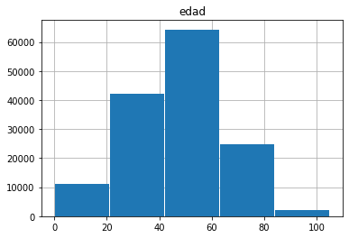

```python
nrows = df.size
print("Numero de filas : "+str(nrows))
print("Porcentaje de genero: ")
print(df['sexo'].value_counts(normalize=True)*100)
print("1.0 = Hombre, 2.0 = Mujer")
df.hist(column='edad', bins=5, zorder=2, rwidth=0.98)
```

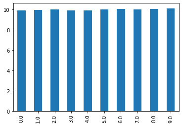

```python
(df['decil'].value_counts(normalize=True)*100).sort_index().plot.bar()
```

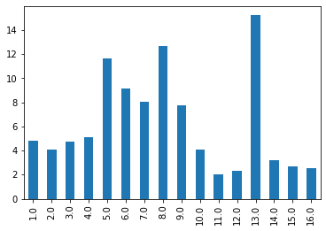

```python
(df['region'].value_counts(normalize=True)*100).sort_index(ascending=True).plot.bar()
```

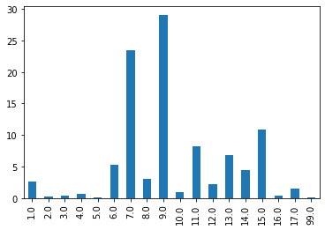

```python
(df['e6a'].value_counts(normalize=True)*100).sort_index(ascending=True).plot.bar()
```

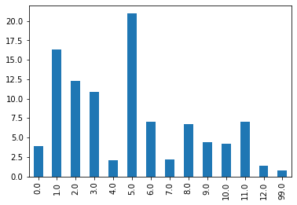

```python
(df['educ'].value_counts(normalize=True)*100).sort_index(ascending=True).plot.bar()
```

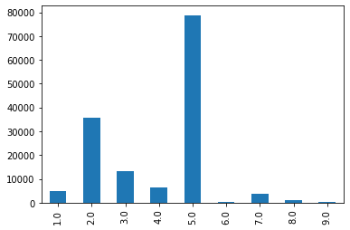

```python
import numpy as np
(df['o15'].value_counts()).sort_index(ascending=True).plot.bar()
np.log10((df['o15'].value_counts()).sort_index(ascending=True)).plot.bar()
```

O15:\ 1 Patrón o empleador\ 2 Trabajador por cuenta propia\ 3 Empleado u Obrero del sector público\ 4 Empleado u Obrero de empresas públicas\ 5 Empleado u Obrero del sector privado\ 6 Servicio doméstico puertas adentro\ 7 Servicio doméstico puertas afuera\ 8 FF.AA. y del Orden\ 9 Familiar no remunerado\

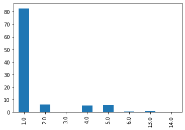

```python
(df['pco2'].value_counts(normalize=True)*100).sort_index(ascending=True).plot.bar()
```

PCO2:

1 Jefe(a) de núcleo\ 2 Esposo(a)/pareja\ 3 Hijo(a) de ambos\ 4 Hijo(a) sólo del jefe\ 5 Hijo(a) sólo de esposo(a)/pareja\ 12 Otro familiar\ 13 Otro no familiar

### Resultados grupo 1

```python
df1 = df
df1=df1[df1['grupo']==0]
df1.head()
```

|  | folio | sexo | edad | region | comuna | zona | año | e6a | educ | o15 | pco2 | decil | grupo |
| --- | --- | --- | --- | --- | --- | --- | --- | --- | --- | --- | --- | --- | --- |
| 35183 | 1.010110e+12 | 2.0 | 36.0 | 10.0 | 10101.0 | 1.0 | 2020 | 14.0 | 9.0 | 2.0 | 1.0 | 4.0 | 0 |
| 35184 | 1.010110e+12 | 1.0 | 59.0 | 10.0 | 10101.0 | 1.0 | 2020 | 15.0 | 10.0 | 4.0 | 1.0 | 4.0 | 0 |
| 35185 | 1.010110e+12 | 1.0 | 68.0 | 10.0 | 10101.0 | 1.0 | 2020 | 9.0 | 5.0 | 4.0 | 1.0 | 1.0 | 0 |
| 35186 | 1.010110e+12 | 2.0 | 0.0 | 10.0 | 10101.0 | 1.0 | 2020 | 1.0 | 0.0 | 5.0 | 5.0 | 1.0 | 0 |
| 35188 | 1.010110e+12 | 1.0 | 4.0 | 10.0 | 10101.0 | 1.0 | 2020 | 4.0 | 0.0 | 3.0 | 4.0 | 5.0 | 0 |

```
Numero de filas : 573937
Porcentaje de genero:
1.0    54.508596
2.0    45.491404
Name: sexo, dtype: float64
1.0 = Hombre, 2.0 = Mujer
```

```
array([[<matplotlib.axes._subplots.AxesSubplot object at 0x7f62b6826590>]],
      dtype=object)
```

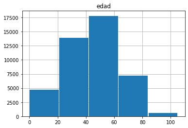

```python
nrows = df1.size
print("Numero de filas : "+str(nrows))
print("Porcentaje de genero: ")
print(df1['sexo'].value_counts(normalize=True)*100)
print("1.0 = Hombre, 2.0 = Mujer")
df1.hist(column='edad', bins=5, zorder=2, rwidth=0.98)
```

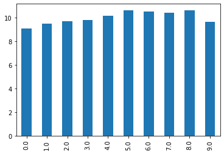

```python
(df1['decil'].value_counts(normalize=True)*100).sort_index().plot.bar()
```

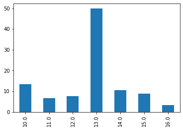

```python
(df1['region'].value_counts(normalize=True)*100).sort_index(ascending=True).plot.bar()
```

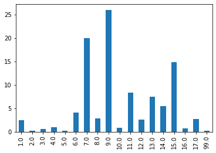

```python
(df1['e6a'].value_counts(normalize=True)*100).sort_index(ascending=True).plot.bar()
```

1 Nunca asistió 8.251 \ 2 Sala cuna 860 \ 3 Jardín Infantil (Medio menor y Medio mayor) 2.577 \ 4 Prekínder / Kínder (Transición menor y Transición Mayor) 4.436 \ 5 Educación Especial (Diferencial) 951 \ 6 Primaria o Preparatoria (Sistema antiguo) 4.467 \ 7 Educación Básica 47.331 \ 8 Humanidades (Sistema Antiguo) 3.988 \ 9 Educación Media Científico-Humanista 48.008 \ 10 Técnica Comercial, Industrial o Normalista (Sistema Antiguo) 1.559 \ 11 Educación Media Técnica Profesional 13.104 \ 12 Técnico Nivel Superior Incompleto (Carreras 1 a 3 años) 5.345 \ 13 Técnico Nivel Superior Completo (Carreras 1 a 3 años) 10.879 \ 14 Profesional Incompleto (Carreras 4 ó más años) 13.227 \ 15 Profesional Completo (Carreras 4 ó más años) 17.956 \ 16 Postgrado Incompleto 608 \ 17 Postgrado Completo \

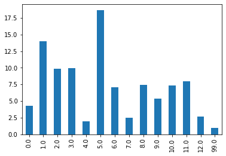

```python
(df1['educ'].value_counts(normalize=True)*100).sort_index(ascending=True).plot.bar()
```

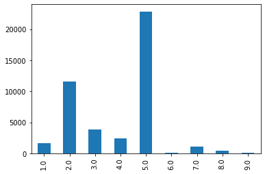

```python
import numpy as np
(df1['o15'].value_counts()).sort_index(ascending=True).plot.bar()
np.log10((df1['o15'].value_counts()).sort_index(ascending=True)).plot.bar()
```

O15:\ 1 Patrón o empleador\ 2 Trabajador por cuenta propia\ 3 Empleado u Obrero del sector público\ 4 Empleado u Obrero de empresas públicas\ 5 Empleado u Obrero del sector privado\ 6 Servicio doméstico puertas adentro\ 7 Servicio doméstico puertas afuera\ 8 FF.AA. y del Orden\ 9 Familiar no remunerado\

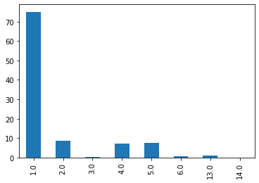

```python
(df1['pco2'].value_counts(normalize=True)*100).sort_index(ascending=True).plot.bar()
```

PCO2:

1 Jefe(a) de núcleo\ 2 Esposo(a)/pareja\ 3 Hijo(a) de ambos\ 4 Hijo(a) sólo del jefe\ 5 Hijo(a) sólo de esposo(a)/pareja\ 12 Otro familiar\ 13 Otro no familiar

### Resultados grupo 2

```python
df1 = df
df1=df1[df1['grupo']==1]
df1.head()
```

|  | folio | sexo | edad | region | comuna | zona | año | e6a | educ | o15 | pco2 | decil | grupo |
| --- | --- | --- | --- | --- | --- | --- | --- | --- | --- | --- | --- | --- | --- |
| 0 | 1.101100e+11 | 2.0 | 34.0 | 1.0 | 1101.0 | 1.0 | 2020 | 9.0 | 5.0 | 2.0 | 1.0 | 2.0 | 1 |
| 1 | 1.101100e+11 | 2.0 | 5.0 | 1.0 | 1101.0 | 1.0 | 2020 | 7.0 | 1.0 | 5.0 | 5.0 | 2.0 | 1 |
| 2 | 1.101100e+11 | 1.0 | 57.0 | 1.0 | 1101.0 | 1.0 | 2020 | 13.0 | 8.0 | 8.0 | 2.0 | 6.0 | 1 |
| 4 | 1.101100e+11 | 1.0 | 11.0 | 1.0 | 1101.0 | 1.0 | 2020 | 7.0 | 1.0 | 5.0 | 5.0 | 6.0 | 1 |
| 5 | 1.101100e+11 | 1.0 | 55.0 | 1.0 | 1101.0 | 1.0 | 2020 | 9.0 | 5.0 | 2.0 | 1.0 | 9.0 | 1 |

```
Numero de filas : 695604
Porcentaje de genero:
1.0    63.612918
2.0    36.387082
Name: sexo, dtype: float64
1.0 = Hombre, 2.0 = Mujer
```

```
array([[<matplotlib.axes._subplots.AxesSubplot object at 0x7f62b65cb4d0>]],
      dtype=object)
```

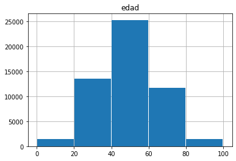

```python
nrows = df1.size
print("Numero de filas : "+str(nrows))
print("Porcentaje de genero: ")
print(df1['sexo'].value_counts(normalize=True)*100)
print("1.0 = Hombre, 2.0 = Mujer")
df1.hist(column='edad', bins=5, zorder=2, rwidth=0.98)
```

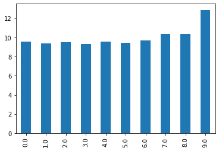

```python
(df1['decil'].value_counts(normalize=True)*100).sort_index().plot.bar()
```

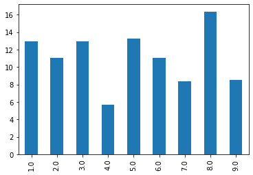

```python
(df1['region'].value_counts(normalize=True)*100).sort_index(ascending=True).plot.bar()
```

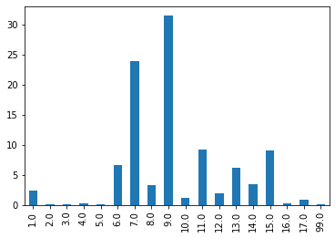

```python
(df1['e6a'].value_counts(normalize=True)*100).sort_index(ascending=True).plot.bar()
```

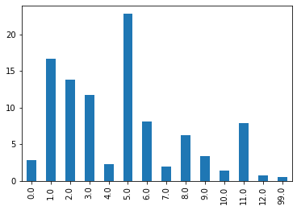

```python
(df1['educ'].value_counts(normalize=True)*100).sort_index(ascending=True).plot.bar()
```

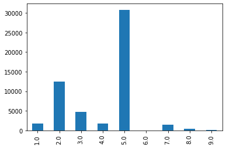

```python
import numpy as np
(df1['o15'].value_counts()).sort_index(ascending=True).plot.bar()
```

O15:\ 1 Patrón o empleador\ 2 Trabajador por cuenta propia\ 3 Empleado u Obrero del sector público\ 4 Empleado u Obrero de empresas públicas\ 5 Empleado u Obrero del sector privado\ 6 Servicio doméstico puertas adentro\ 7 Servicio doméstico puertas afuera\ 8 FF.AA. y del Orden\ 9 Familiar no remunerado\

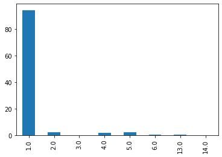

```python
(df1['pco2'].value_counts(normalize=True)*100).sort_index(ascending=True).plot.bar()
```

PCO2:

1 Jefe(a) de núcleo\ 2 Esposo(a)/pareja\ 3 Hijo(a) de ambos\ 4 Hijo(a) sólo del jefe\ 5 Hijo(a) sólo de esposo(a)/pareja\ 12 Otro familiar\ 13 Otro no familiar

```python
df1 = df
df1=df1[df1['grupo']==2]
df1.head()
```

|  | folio | sexo | edad | region | comuna | zona | año | e6a | educ | o15 | pco2 | decil | grupo |
| --- | --- | --- | --- | --- | --- | --- | --- | --- | --- | --- | --- | --- | --- |
| 7465 | 4.101100e+11 | 1.0 | 62.0 | 4.0 | 4101.0 | 1.0 | 2020 | 14.0 | 9.0 | 2.0 | 1.0 | 4.0 | 2 |
| 7467 | 4.101100e+11 | 2.0 | 62.0 | 4.0 | 4101.0 | 1.0 | 2020 | 12.0 | 7.0 | 3.0 | 1.0 | 4.0 | 2 |
| 7470 | 4.101100e+11 | 1.0 | 30.0 | 4.0 | 4101.0 | 1.0 | 2020 | 9.0 | 5.0 | 5.0 | 5.0 | 4.0 | 2 |
| 7471 | 4.101100e+11 | 1.0 | 18.0 | 4.0 | 4101.0 | 1.0 | 2020 | 9.0 | 3.0 | 5.0 | 6.0 | 4.0 | 2 |
| 7472 | 4.101100e+11 | 1.0 | 57.0 | 4.0 | 4101.0 | 1.0 | 2020 | 7.0 | 1.0 | 2.0 | 1.0 | 4.0 | 2 |

```
Numero de filas : 610012
Porcentaje de genero:
1.0    56.067258
2.0    43.932742
Name: sexo, dtype: float64
1.0 = Hombre, 2.0 = Mujer
```

```
array([[<matplotlib.axes._subplots.AxesSubplot object at 0x7f62b55582d0>]],
      dtype=object)
```

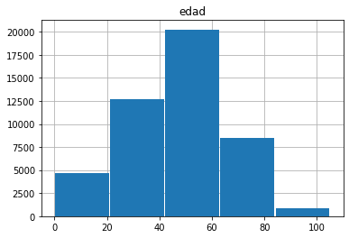

```python
nrows = df1.size
print("Numero de filas : "+str(nrows))
print("Porcentaje de genero: ")
print(df1['sexo'].value_counts(normalize=True)*100)
print("1.0 = Hombre, 2.0 = Mujer")
df1.hist(column='edad', bins=5, zorder=2, rwidth=0.98)
```

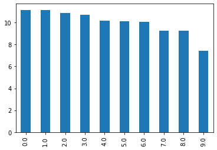

```python
(df1['decil'].value_counts(normalize=True)*100).sort_index().plot.bar()
```

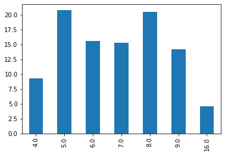

```python
(df1['region'].value_counts(normalize=True)*100).sort_index(ascending=True).plot.bar()
```

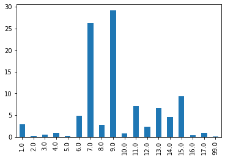

```python
(df1['e6a'].value_counts(normalize=True)*100).sort_index(ascending=True).plot.bar()
```

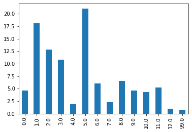

```python
(df1['educ'].value_counts(normalize=True)*100).sort_index(ascending=True).plot.bar()
```

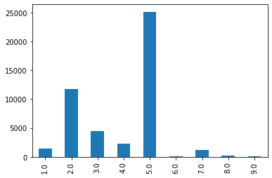

```python
import numpy as np
(df1['o15'].value_counts()).sort_index(ascending=True).plot.bar()
```

O15:\ 1 Patrón o empleador\ 2 Trabajador por cuenta propia\ 3 Empleado u Obrero del sector público\ 4 Empleado u Obrero de empresas públicas\ 5 Empleado u Obrero del sector privado\ 6 Servicio doméstico puertas adentro\ 7 Servicio doméstico puertas afuera\ 8 FF.AA. y del Orden\ 9 Familiar no remunerado

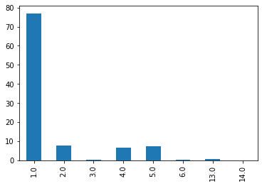

```python
(df1['pco2'].value_counts(normalize=True)*100).sort_index(ascending=True).plot.bar()
```

PCO2:

1 Jefe(a) de núcleo\ 2 Esposo(a)/pareja\ 3 Hijo(a) de ambos\ 4 Hijo(a) sólo del jefe\ 5 Hijo(a) sólo de esposo(a)/pareja\ 12 Otro familiar\ 13 Otro no familiar

## Pregunta 5

```python
import warnings
warnings.filterwarnings('ignore')
from sklearn.cluster import KMeans
from scipy.cluster.hierarchy import dendrogram, linkage
from sklearn.cluster import AgglomerativeClustering
from sklearn.ensemble import VotingClassifier
from sklearn.neighbors import KNeighborsClassifier
from sklearn.tree import DecisionTreeClassifier
from sklearn.naive_bayes import CategoricalNB, GaussianNB
```

### Parte 1

```python
COLUMNAS_INGRESOS = ['folio', 'ytoth', 'region', 'comuna', 'zona', 'año','numper',"e6a","pco1","edad","sexo"]

def filtrar_ingresos(data: pd.DataFrame) -> pd.DataFrame:
  """ Filtra las columnas relevantes al analisis de ingresos"""
  new_data_frame = data[COLUMNAS_INGRESOS]
  new_data_frame = new_data_frame.groupby(['folio']).first().reset_index()
  new_data_frame.reset_index(drop=True, inplace=True)

  # Chequeo de que se hizo bien la agrupación
  folio_count = data['folio'].nunique()
  new_data_row_count = len(new_data_frame)
  assert folio_count == new_data_row_count

  return new_data_frame
```

```python
df_ingresos_2013 = filtrar_ingresos(df2013)
df_ingresos_2013.name = "Casen 2013 Ingresos"

df_ingresos_2015 = filtrar_ingresos(df2015)
df_ingresos_2015.name = "Casen 2015 Ingresos"

df_ingresos_2017 = filtrar_ingresos(df2017)
df_ingresos_2017.name = "Casen 2017 Ingresos"

df_ingresos_2020 = filtrar_ingresos(df2020)
df_ingresos_2020.name = "Casen 2020 Ingresos"

df_ingresos_all = pd.concat([df_ingresos_2020, df_ingresos_2017,df_ingresos_2015,df_ingresos_2013], ignore_index=True)
df_ingresos_all
```

|  | folio | ytoth | region | comuna | zona | año | numper | e6a | pco1 | edad | sexo |
| --- | --- | --- | --- | --- | --- | --- | --- | --- | --- | --- | --- |
| 0 | 1.101100e+11 | 390833.0 | 1.0 | 1101.0 | 1.0 | 2020.0 | 2.0 | 9.0 | 1.0 | 34.0 | 2.0 |
| 1 | 1.101100e+11 | 947583.0 | 1.0 | 1101.0 | 1.0 | 2020.0 | 3.0 | 7.0 | 5.0 | 5.0 | 2.0 |
| 2 | 1.101100e+11 | 3004167.0 | 1.0 | 1101.0 | 1.0 | 2020.0 | 3.0 | 13.0 | 2.0 | 57.0 | 1.0 |
| 3 | 1.101100e+11 | 610250.0 | 1.0 | 1101.0 | 1.0 | 2021.0 | 2.0 | 10.0 | 1.0 | 77.0 | 1.0 |
| 4 | 1.101100e+11 | 1321481.0 | 1.0 | 1101.0 | 1.0 | 2020.0 | 4.0 | 7.0 | 5.0 | 11.0 | 1.0 |
| ... | ... | ... | ... | ... | ... | ... | ... | ... | ... | ... | ... |
| 284466 | 1.520130e+11 | 377507.0 | 15.0 | 15201.0 | 2.0 | 2013.0 | 1.0 | 8.0 | 1.0 | 31.0 | 2.0 |
| 284467 | 1.520130e+11 | 330783.0 | 15.0 | 15201.0 | 2.0 | 2013.0 | 1.0 | 5.0 | 1.0 | 68.0 | 1.0 |
| 284468 | 1.520130e+11 | 298000.0 | 15.0 | 15201.0 | 2.0 | 2013.0 | 4.0 | 6.0 | 1.0 | 49.0 | 1.0 |
| 284469 | 1.520130e+11 | 360000.0 | 15.0 | 15201.0 | 2.0 | 2013.0 | 5.0 | 6.0 | 1.0 | 30.0 | 1.0 |
| 284470 | 1.520130e+11 | 125000.0 | 15.0 | 15201.0 | 2.0 | 2013.0 | 1.0 | 6.0 | 1.0 | 62.0 | 2.0 |

284471 rows × 11 columns

```python
def metodo_codo(x, titulo):
  sse = []

  clusters = list(range(1, 16))
  for k in clusters:
      kmeans = KMeans(n_clusters=k).fit(x)
      sse.append(kmeans.inertia_)

  plt.plot(clusters, sse, marker="o")
  plt.title(titulo)
  plt.grid(True)
  plt.show()
```

```python
def plot_kmeans(data,random_satate, n_clusters,nombre):
    kmeans = KMeans(n_clusters=n_clusters, random_state=random_state).fit(data)
    plt.scatter(data[:, 0], data[:, 1], c=kmeans.labels_)
    plt.title(nombre)
    plt.show()

def plot_kmeans3D(data,random_satate, n_clusters,nombre):
    kmeans = KMeans(n_clusters=n_clusters, random_state=random_state).fit(data)
    fig = plt.figure(figsize=(6,6))
    ax = fig.add_subplot(111, projection='3d')
    ax.scatter(data[:, 0], data[:, 1],data[:,2], c=kmeans.labels_)
    plt.title(nombre)
    plt.show()
random_state = 20
```

```python
df_2013_jefes = df_ingresos_2013.loc[df_ingresos_2013["pco1"] == 1][["numper","ytoth","region","e6a","comuna"]]
df_2015_jefes = df_ingresos_2015.loc[df_ingresos_2015["pco1"] == 1][["numper","ytoth","region","e6a","comuna"]]
df_2017_jefes = df_ingresos_2017.loc[df_ingresos_2017["pco1"] == 1][["numper","ytoth","region","e6a","comuna"]]
df_2020_jefes = df_ingresos_2020.loc[df_ingresos_2020["pco1"] == 1][["numper","ytoth","region","e6a","comuna"]]
df_all_jefes = pd.concat([df_2020_jefes, df_2017_jefes,df_2015_jefes,df_2013_jefes], ignore_index=True)
```

```python
#Limpieza
df_2013_jefes2 = df_2013_jefes[(df_2013_jefes["ytoth"]<20000000) & (df_2013_jefes["numper"]<12)]
df_2015_jefes2 = df_2015_jefes[(df_2015_jefes["ytoth"]<20000000) & (df_2015_jefes["numper"]<12)]
df_2017_jefes2 = df_2017_jefes[(df_2017_jefes["ytoth"]<20000000) & (df_2017_jefes["numper"]<12)]
df_2020_jefes2 = df_2020_jefes[(df_2020_jefes["ytoth"]<20000000) & (df_2020_jefes["numper"]<12)]
df_all_jefes2 = df_all_jefes[(df_all_jefes["ytoth"]<20000000) & (df_all_jefes["numper"]<12)]
```

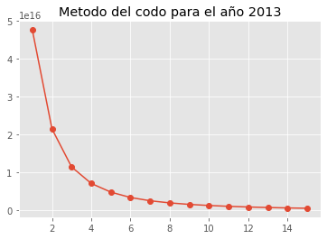

```python
metodo_codo(df_2013_jefes2.dropna().reset_index(drop=True),"Metodo del codo para el año 2013")
```

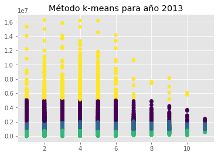

```python
plot_kmeans(df_2013_jefes2[["numper","ytoth"]].to_numpy(), random_state, 4, "Método k-means para año 2013")
```

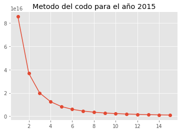

```python
metodo_codo(df_2015_jefes2,"Metodo del codo para el año 2015")
```

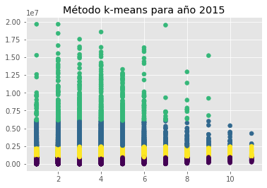

```python
plot_kmeans(df_2015_jefes2[["numper","ytoth"]].to_numpy(), random_state, 4, "Método k-means para año 2015")
```

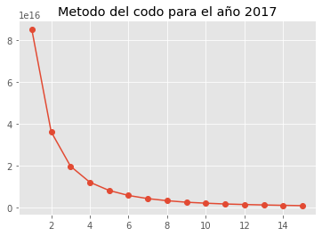

```python
metodo_codo(df_2017_jefes2,"Metodo del codo para el año 2017")
```

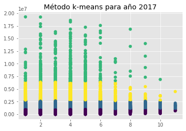

```python
plot_kmeans(df_2017_jefes2[["numper","ytoth"]].to_numpy(), random_state, 4,  "Método k-means para año 2017")
```

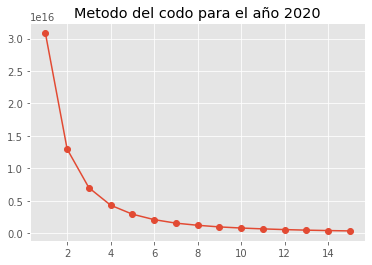

```python
metodo_codo(df_2020_jefes2,"Metodo del codo para el año 2020")
```

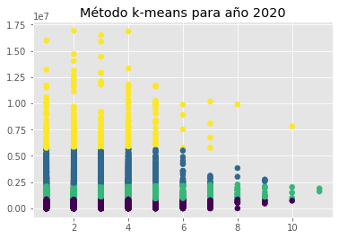

```python
plot_kmeans(df_2020_jefes2[["numper","ytoth"]].to_numpy(), random_state, 4,  "Método k-means para año 2020")
```

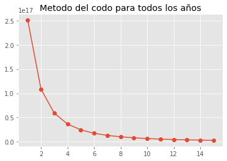

```python
metodo_codo(df_all_jefes2,"Metodo del codo para todos los años")
```

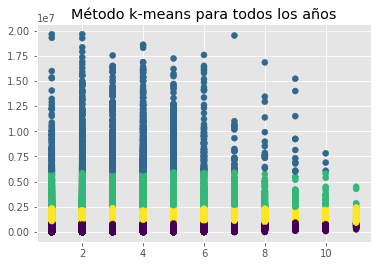

```python
plot_kmeans(df_all_jefes2[["numper","ytoth"]].to_numpy(), random_state, 4, "Método k-means para todos los años")
```

No existen resultados deslutivos, esto dado que la variable numper es discreta y muy repetitiva, dado esto, se decide considerar una tercera variable "e6a" la cual corresponde a educación, para ver si podemos rescautar alguna relación de interés.

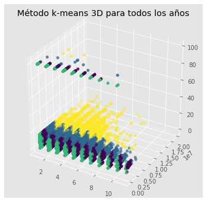

```python
plot_kmeans3D(df_all_jefes2[["numper","ytoth","e6a"]].dropna().reset_index(drop=True).to_numpy(), random_state, 4, "Método k-means 3D para todos los años")
```

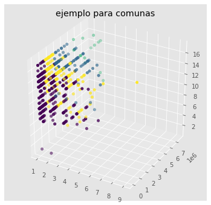

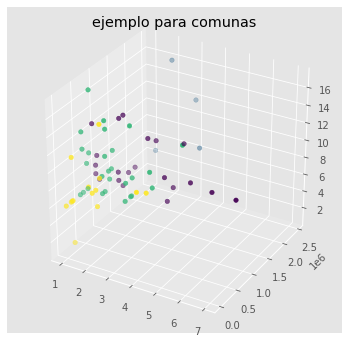

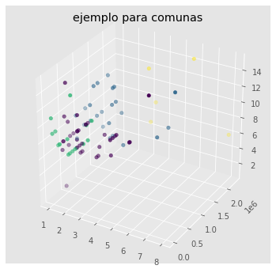

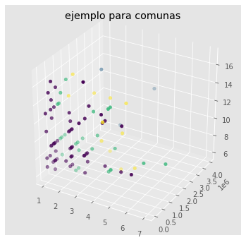

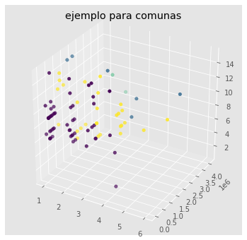

```python
#Se rescata el nombre de las comunas de la region metropolitana
aux = df_2020_jefes2[df_2020_jefes2["region"]==13]
comunas_santiago = np.array(aux["comuna"].unique().tolist())

for i in range(0,5):
    df_aux = df_2020_jefes2[df_2020_jefes2["comuna"] == comunas_santiago[i]]
    plot_kmeans3D(df_aux[["numper","ytoth","e6a"]].dropna().reset_index(drop=True).to_numpy(), random_state, 4, "ejemplo para comunas")
```

Es dificil precisar un rasultado, con más tiempo se podrían haber agrupado las comunas por sectores, segregar incluso por resultados políticos, como puede ser las presidenciales o la aprobación de la convención constitucional.

```python
def plot_dendo(datos, region,tipo):
    dendrogram(linkage(datos, method = tipo))
    plt.title("Linkage: " + tipo + " para la region" + str(region))
    plt.show()
```

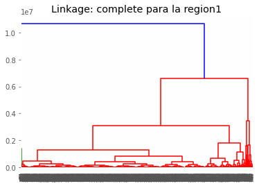

```python
plot_dendo(df_2013_jefes2[df_2013_jefes2['region'] == 1], 1, "complete")
```

[figure not shown]

```python
complete_3 = AgglomerativeClustering(n_clusters=5, linkage="complete").fit(df_2013_jefes2[df_2013_jefes2['region'] == 1])

X = df_2013_jefes2[df_2013_jefes2['region'] == 1].to_numpy()
plt.scatter(X[:, 0], X[:, 1], c=complete_3.labels_)
plt.title("Hierarchical: complete, 3 clusters")
plt.show()
```

### Parte 2

```python
df_ingresos_2020.pco1.value_counts()
```

```
1     28435
2     10546
5      9288
4      7991
10     2488
7       891
11      804
13      804
6       451
9       392
14      355
8       211
12      128
3       102
15       25
Name: pco1, dtype: int64
```

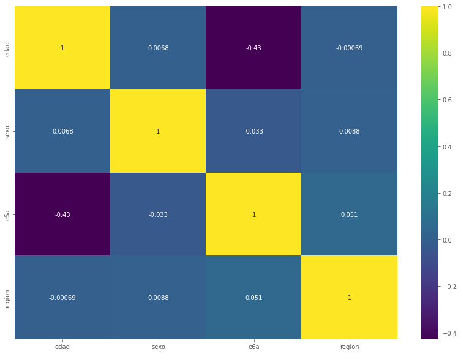

```python
df_2020_relacion = df_ingresos_2020.loc[(df_ingresos_2020["pco1"] == 1) | (df_ingresos_2020["pco1"] == 2)]
plt.figure(figsize=(14, 10))
sns.heatmap(df_2020_relacion[['edad', 'sexo', 'e6a','region']].corr(), cmap='viridis', annot=True);
```

```python
def getXy(df, columnasX, columnaY):
  X = df.loc[:,columnasX].to_numpy()
  y = df.loc[:,columnaY].to_numpy()
  return X, y

columnasClasRegion = ["edad","sexo","region"]
X2020, y2020 = getXy(df_2020_relacion, columnasClasRegion, 'e6a')
```

```python
def run_classifier(clf, X, y, num_tests=100):
    metrics = {'f1-score': [], 'precision': [], 'recall': []}

    for _ in range(num_tests):
        X_train, X_test, y_train, y_test = train_test_split(X, y, test_size=.30)
        ### INICIO COMPLETAR ACÁ

        #### TIP: en base a los set de entrenamiento, genere la variable 'predictions'
        #### que contiene las predicciones del modelo
        clf.fit(X_train, y_train)
        predictions = clf.predict(X_test)


        ### FIN COMPLETAR ACÁ

        metrics['y_pred'] = predictions
        metrics['f1-score'].append(f1_score(y_test, predictions, average='weighted'))
        metrics['recall'].append(recall_score(y_test, predictions, average='weighted'))
        metrics['precision'].append(precision_score(y_test, predictions, average='weighted'))
    return metrics
```

```python
voting_clf = VotingClassifier(
     estimators=[('KNN', KNeighborsClassifier()), ('Des Tree', DecisionTreeClassifier()), ('Bayes', GaussianNB())],
     voting='hard')

name = "voting_clf"
metrics = run_classifier(voting_clf, X2020, y2020)
print("----------------")
print("Resultados para clasificador: ", name)
print("Precision promedio:", np.array(metrics['precision']).mean())
print("Recall promedio:", np.array(metrics['recall']).mean())
print("F1-score promedio:", np.array(metrics['f1-score']).mean())
print("----------------\n\n")
```

```
----------------
Resultados para clasificador:  voting_clf
Precision promedio: 0.24853629927709264
Recall promedio: 0.29823599828986747
F1-score promedio: 0.24635312503408024
----------------
```

Se obtiene malos resultados, por lo que se intenta mejorar a través de otros métodos. Se procede a juntar los valores que pco1 que tengan afinidad, luego se seleccionan los 3 valores más parecidos.

```python
df_2013_relacion2 = df_ingresos_2013
df_2013_relacion2.loc[df_2013_relacion2["pco1"] == 3, "pco1"] = 4 # Se igualan factores relacionados a los hijos
df_2013_relacion2.loc[df_2013_relacion2["pco1"] == 4, "pco1"] = 4
df_2013_relacion2.loc[df_2013_relacion2["pco1"] == 5, "pco1"] = 4

df_2015_relacion2 = df_ingresos_2015
df_2015_relacion2.loc[df_2015_relacion2["pco1"] == 3, "pco1"] = 2 # esposo = esposa
df_2015_relacion2.loc[df_2015_relacion2["pco1"] == 5, "pco1"] = 4 # Se igualan factores relacionados a los hijos
df_2015_relacion2.loc[df_2015_relacion2["pco1"] == 6, "pco1"] = 4

df_2017_relacion2 = df_ingresos_2017
df_2017_relacion2.loc[df_2017_relacion2["pco1"] == 3, "pco1"] = 2 # esposo = esposa
df_2017_relacion2.loc[df_2017_relacion2["pco1"] == 5, "pco1"] = 4 # Se igualan factores relacionados a los hijos
df_2017_relacion2.loc[df_2017_relacion2["pco1"] == 6, "pco1"] = 4

df_2020_relacion2 = df_ingresos_2020
df_2020_relacion2.loc[df_2020_relacion2["pco1"] == 3, "pco1"] = 2 # esposo = esposa
df_2020_relacion2.loc[df_2020_relacion2["pco1"] == 5, "pco1"] = 4 # Se igualan factores relacionados a los hijos
df_2020_relacion2.loc[df_2020_relacion2["pco1"] == 6, "pco1"] = 4
df_2020_relacion2
```

|  | folio | ytoth | region | comuna | zona | año | numper | e6a | pco1 | edad | sexo |
| --- | --- | --- | --- | --- | --- | --- | --- | --- | --- | --- | --- |
| 0 | 1.101100e+11 | 390833 | 1 | 1101 | 1 | 2020 | 2 | 9 | 1 | 34 | 2 |
| 1 | 1.101100e+11 | 947583 | 1 | 1101 | 1 | 2020 | 3 | 7 | 4 | 5 | 2 |
| 2 | 1.101100e+11 | 3004167 | 1 | 1101 | 1 | 2020 | 3 | 13 | 2 | 57 | 1 |
| 3 | 1.101100e+11 | 610250 | 1 | 1101 | 1 | 2021 | 2 | 10 | 1 | 77 | 1 |
| 4 | 1.101100e+11 | 1321481 | 1 | 1101 | 1 | 2020 | 4 | 7 | 4 | 11 | 1 |
| ... | ... | ... | ... | ... | ... | ... | ... | ... | ... | ... | ... |
| 62906 | 1.630530e+12 | 319158 | 16 | 16305 | 2 | 2020 | 1 | 1 | 1 | 76 | 1 |
| 62907 | 1.630530e+12 | 535104 | 16 | 16305 | 2 | 2020 | 3 | 9 | 1 | 40 | 2 |
| 62908 | 1.630530e+12 | 427417 | 16 | 16305 | 2 | 2021 | 2 | 11 | 2 | 67 | 2 |
| 62909 | 1.630530e+12 | 273750 | 16 | 16305 | 2 | 2021 | 4 | 11 | 4 | 21 | 1 |
| 62910 | 1.630530e+12 | 0 | 16 | 16305 | 2 | 2020 | 3 | 14 | 4 | 29 | 2 |

62911 rows × 11 columns

```python
df_2013_relacion2 = df_2013_relacion2
# Nunca asistio, sala cuna, jardin infantil, kinder [1]
df_2013_relacion2.loc[df_2013_relacion2["e6a"] == 2, "e6a"] = 1
df_2013_relacion2.loc[df_2013_relacion2["e6a"] == 3, "e6a"] = 1

#Se elimina la educacion diferencial por temas prácticos

#Primaria y preparatoria [2]
df_2013_relacion2.loc[df_2013_relacion2["e6a"] == 5, "e6a"] = 2
df_2013_relacion2.loc[df_2013_relacion2["e6a"] == 6, "e6a"] = 2

#Humanidades, ed media, tecnico
df_2013_relacion2.loc[df_2013_relacion2["e6a"] == 7, "e6a"] = 3
df_2013_relacion2.loc[df_2013_relacion2["e6a"] == 8, "e6a"] = 3
df_2013_relacion2.loc[df_2013_relacion2["e6a"] == 9, "e6a"] = 3
df_2013_relacion2.loc[df_2013_relacion2["e6a"] == 10, "e6a"] = 3

#Tecnico sup, profesional
df_2013_relacion2.loc[df_2013_relacion2["e6a"] == 11, "e6a"] = 4
df_2013_relacion2.loc[df_2013_relacion2["e6a"] == 12, "e6a"] = 4
df_2013_relacion2.loc[df_2013_relacion2["e6a"] == 13, "e6a"] = 4


#Se borra la ed diferencial dado que solo son 265 datos
df_2013_relacion2 = df_2013_relacion2[df_2013_relacion2.e6a != 5]

df_2013_relacion2.e6a.value_counts()
```

```
3     27783
2     24029
4     12218
1      2471
99      224
Name: e6a, dtype: int64
```

```python
#Los datos 2015. 2017 y 2020 vienen separados de la misma forma, por lo que se hace una funcion auxiliar.
def change_parameters(datos):
    # Nunca asistio, sala cuna, jardin infantil, kinder [1]
    datos.loc[datos["e6a"] == 2, "e6a"] = 1
    datos.loc[datos["e6a"] == 3, "e6a"] = 1
    datos.loc[datos["e6a"] == 4, "e6a"] = 1

    #Primaria y preparatoria [2]
    datos.loc[datos["e6a"] == 6, "e6a"] = 2
    datos.loc[datos["e6a"] == 7, "e6a"] = 2

    #Humanidades, ed media, tecnico
    datos.loc[datos["e6a"] == 8, "e6a"] = 3
    datos.loc[datos["e6a"] == 9, "e6a"] = 3
    datos.loc[datos["e6a"] == 10, "e6a"] = 3
    datos.loc[datos["e6a"] == 11, "e6a"] = 3

    #Tecnico sup, profesional
    datos.loc[datos["e6a"] == 12, "e6a"] = 4
    datos.loc[datos["e6a"] == 13, "e6a"] = 4
    datos.loc[datos["e6a"] == 14, "e6a"] = 4
    datos.loc[datos["e6a"] == 15, "e6a"] = 4
    datos.loc[datos["e6a"] == 16, "e6a"] = 4
    datos.loc[datos["e6a"] == 17, "e6a"] = 4

    #Se borra la ed diferencial dado que solo son 265 datos
    datos = datos[datos.e6a != 5]
```

```python
change_parameters(df_2020_relacion2)
df_2020_relacion2.e6a.value_counts()
```

```
3    22697
4    17818
2    17643
1     4487
5      266
Name: e6a, dtype: int64
```

```python
change_parameters(df_2017_relacion2)
df_2017_relacion2.e6a.value_counts()
```

```
3.0     29231
2.0     22464
4.0     17010
1.0      2018
99.0      195
5.0        30
Name: e6a, dtype: int64
```

```python
change_parameters(df_2015_relacion2)
df_2015_relacion2.e6a.value_counts()
```

```
3     34414
2     29470
4     17206
1      2707
99       65
5        25
Name: e6a, dtype: int64
```

```python
df_2020_relacion2 = df_2020_relacion2.loc[(df_2020_relacion2["pco1"] == 1) | (df_2020_relacion2["pco1"] == 2) | (df_2020_relacion2["pco1"] == 4)]
df_2017_relacion2 = df_2017_relacion2.loc[(df_2017_relacion2["pco1"] == 1) | (df_2017_relacion2["pco1"] == 2) | (df_2017_relacion2["pco1"] == 4)]
df_2015_relacion2 = df_2015_relacion2.loc[(df_2015_relacion2["pco1"] == 1) | (df_2015_relacion2["pco1"] == 2) | (df_2015_relacion2["pco1"] == 4)]
df_2013_relacion2 = df_2013_relacion2.loc[(df_2013_relacion2["pco1"] == 1) | (df_2013_relacion2["pco1"] == 2) | (df_2013_relacion2["pco1"] == 4)]
df_all_relacion2 = pd.concat([df_2020_relacion2, df_2017_relacion2,df_2015_relacion2,df_2013_relacion2], ignore_index=True)
```

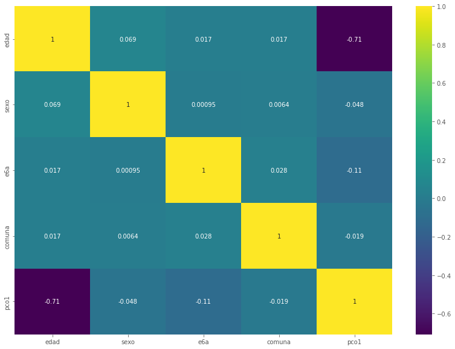

```python
plt.figure(figsize=(14, 10))
sns.heatmap(df_2020_relacion2[['edad', 'sexo', 'e6a',"comuna","pco1"]].corr(), cmap='viridis', annot=True)
```

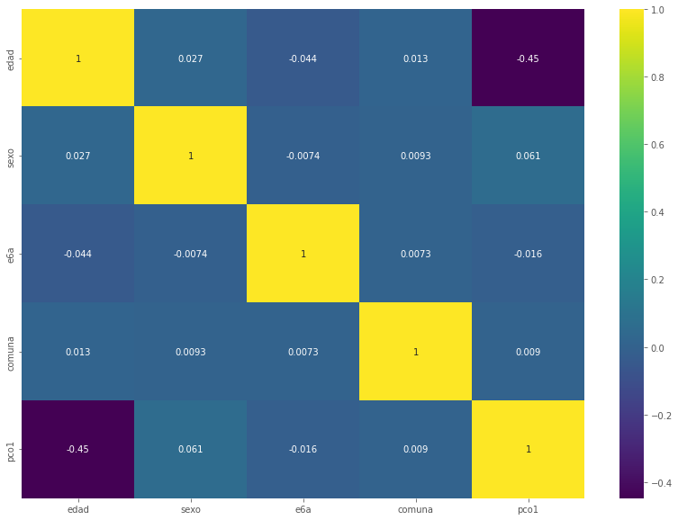

```python
plt.figure(figsize=(14, 10))
sns.heatmap(df_all_relacion2[['edad', 'sexo', 'e6a',"comuna","pco1"]].corr(), cmap='viridis', annot=True);
```

```python
columnasClasRegion = ["edad","comuna","sexo","pco1"]
X2020, y2020 = getXy(df_2020_relacion2, columnasClasRegion, 'e6a')

voting_clf = VotingClassifier(
     estimators=[('KNN', KNeighborsClassifier()), ('Des Tree', DecisionTreeClassifier()), ('Gaussian', GaussianNB())],
     voting='hard')

name = "voting_clf"
metrics = run_classifier(voting_clf, X2020, y2020)
print("----------------")
print("Resultados para clasificador: ", name)
print("Precision promedio:", np.array(metrics['precision']).mean())
print("Recall promedio:", np.array(metrics['recall']).mean())
print("F1-score promedio:", np.array(metrics['f1-score']).mean())
print("----------------\n\n")
```

```
----------------
Resultados para clasificador:  voting_clf
Precision promedio: 0.5416828599072075
Recall promedio: 0.5382298756160525
F1-score promedio: 0.5377588762802802
----------------
```

```python
columnasClasRegion = ["edad","comuna","sexo","pco1"]
X2020, y2020 = getXy(df_all_relacion2, columnasClasRegion, 'e6a')

voting_clf = VotingClassifier(
     estimators=[('KNN', KNeighborsClassifier()), ('Des Tree', DecisionTreeClassifier()), ('Gaussian', GaussianNB())],
     voting='hard')

name = "voting_clf"
metrics = run_classifier(voting_clf, X2020, y2020)
print("----------------")
print("Resultados para clasificador: ", name)
print("Precision promedio:", np.array(metrics['precision']).mean())
print("Recall promedio:", np.array(metrics['recall']).mean())
print("F1-score promedio:", np.array(metrics['f1-score']).mean())
print("----------------\n\n")
```

```
----------------
Resultados para clasificador:  voting_clf
Precision promedio: 0.5178821964015218
Recall promedio: 0.5072208784366318
F1-score promedio: 0.49515548687702043
----------------
```

## Bonus

### Parte 1

```python
df_2013_bonus = df_ingresos_2013.loc[(df_ingresos_2013["pco1"] == 1) & (df_ingresos_2013["sexo"] == 2)]
df_2015_bonus = df_ingresos_2015.loc[(df_ingresos_2015["pco1"] == 1) & (df_ingresos_2015["sexo"] == 2)]
df_2017_bonus = df_ingresos_2017.loc[(df_ingresos_2017["pco1"] == 1) & (df_ingresos_2017["sexo"] == 2)]
df_2020_bonus = df_ingresos_2020.loc[(df_ingresos_2020["pco1"] == 1) & (df_ingresos_2020["sexo"] == 2)]
```

```python
print("Porcentaje para 2013: ", (df_2013_bonus.size/df_ingresos_2013.size)*100)
print("Porcentaje para 2015: ", (df_2015_bonus.size/df_ingresos_2015.size)*100)
print("Porcentaje para 2017: ", (df_2017_bonus.size/df_ingresos_2017.size)*100)
print("Porcentaje para 2020: ", (df_2020_bonus.size/df_ingresos_2020.size)*100)
```

```
Porcentaje para 2013:  37.2079430498314
Porcentaje para 2015:  37.94390072359245
Porcentaje para 2017:  41.57692958222924
Porcentaje para 2020:  23.60477499960261
```

### Parte 2

```python
df_2013_bonus2 = df_ingresos_2013[["folio","ytoth","region","comuna"]]
df_2015_bonus2 = df_ingresos_2015[["folio","ytoth","region","comuna"]]
df_2017_bonus2 = df_ingresos_2017[["folio","ytoth","region","comuna"]]
df_2020_bonus2 = df_ingresos_2020[["folio","ytoth","region","comuna"]]
df_all_bonus2 = pd.concat([df_2013_bonus2, df_2015_bonus2,df_2017_bonus2,df_2020_bonus2], ignore_index=True)
df_all_bonus2
```

|  | folio | ytoth | region | comuna |
| --- | --- | --- | --- | --- |
| 0 | 1.101100e+10 | 1900000.0 | 1.0 | 1101.0 |
| 1 | 1.101100e+10 | 453346.0 | 1.0 | 1101.0 |
| 2 | 1.101100e+10 | 1070000.0 | 1.0 | 1101.0 |
| 3 | 1.101100e+10 | 1091667.0 | 1.0 | 1101.0 |
| 4 | 1.101100e+10 | 766679.0 | 1.0 | 1101.0 |
| ... | ... | ... | ... | ... |
| 284466 | 1.630530e+12 | 319158.0 | 16.0 | 16305.0 |
| 284467 | 1.630530e+12 | 535104.0 | 16.0 | 16305.0 |
| 284468 | 1.630530e+12 | 427417.0 | 16.0 | 16305.0 |
| 284469 | 1.630530e+12 | 273750.0 | 16.0 | 16305.0 |
| 284470 | 1.630530e+12 | 0.0 | 16.0 | 16305.0 |

284471 rows × 4 columns

```python
ingresos_region = df_all_bonus2.groupby('region', as_index = False).agg({'ytoth':'sum','folio':'max','comuna':'max'})['ytoth'].to_numpy()
ingresos_region
print("Porcentaje promedio de menos ingresos que tienen las regiones en comparación a la RM")
porcentajes = [None] * len(ingresos_region)
for i in range(len(ingresos_region)):

    porcentajes[i] = (((ingresos_region[12] - ingresos_region[i])/4)/ingresos_region[12])*100 #se divide en 4 dado que son 4 encuestas casen
    print(porcentajes[i])

print("Porcentaje promedio de todas las regiones")
count = 0
for i in range(len(porcentajes)):
    count += porcentajes[i]

print("promedio: ",count/(len(porcentajes)-1))
```

```
Porcentaje promedio de menos ingresos que tienen las regiones en comparación a la RM
21.20102022234772
21.189688710299265
21.154426942871023
21.644616166156688
16.73671625053076
19.4089594579672
20.38398759095109
16.70375504561449
20.102835689188492
20.43432071167884
22.67259636776822
21.764305556248285
0.0
21.71944350150469
22.617953026214497
23.835962458771487
Porcentaje promedio de todas las regiones
promedio:  20.771372513207513
```

```python
df_all_bonus2 = df_all_bonus2.loc[df_all_bonus2["region"] == 13]
ingresos_comuna = df_all_bonus2.groupby('comuna', as_index = False).agg({'ytoth':'sum','folio':'max','region':'max'}).to_numpy()

for i in range(len(ingresos_comuna)):
    for j in range(len(ingresos_region)):
        if ingresos_comuna[i][1]>ingresos_region[j]:
            print("La comuna ", ingresos_comuna[i][0], "Tiene más ingresos que la region", j+1)
```

```
La comuna  13101.0 Tiene más ingresos que la region 16
La comuna  13114.0 Tiene más ingresos que la region 4
La comuna  13114.0 Tiene más ingresos que la region 11
La comuna  13114.0 Tiene más ingresos que la region 12
La comuna  13114.0 Tiene más ingresos que la region 14
La comuna  13114.0 Tiene más ingresos que la region 15
La comuna  13114.0 Tiene más ingresos que la region 16
La comuna  13119.0 Tiene más ingresos que la region 16
La comuna  13120.0 Tiene más ingresos que la region 16
La comuna  13123.0 Tiene más ingresos que la region 11
La comuna  13123.0 Tiene más ingresos que la region 15
La comuna  13123.0 Tiene más ingresos que la region 16
La comuna  13132.0 Tiene más ingresos que la region 16
La comuna  13201.0 Tiene más ingresos que la region 16
```

```python
#Los ingresos son totales, correspondientes a las 4 encuestas Casen
#13101 = Comuna Santiago
#13114 = Comuna Las Condes
#13119 = Comuna Maipú
#13120 = Comuna Ñuñoa
#13123 = Comuna Providencia
#13201 = Puente Alto
```

# Anexos

## Fuentes externas:

### Links:

- http://observatorio.ministeriodesarrollosocial.gob.cl/encuesta-casen Página web de donde se obtuvieron los datos de las encuestas CASEN de los años 2013, 2015 y 2017.
- http://observatorio.ministeriodesarrollosocial.gob.cl/encuesta-casen-en-pandemia-2020 Página web de donde se obtuvieron los datos de la encuesta CASEN del año 2020.
- https://datasocial.ministeriodesarrollosocial.gob.cl/ Página web que funcionó como motivante para el proyecto, además fue consultada un par de veces en el desarrollo y análisis de datos.
- https://www.desarrollosocialyfamilia.gob.cl/informacion-social Página web general en donde se encontraron links relacionados al análisis de datos

### Tutoriales y Laboratorios:

Escenciales para la elaboración del código del trabajo, sobre todo cuando nos tuvimos que guiar por códigos genéricos, como el método del "codo", matriz de correolación, etc.

```python
%%shell
jupyter nbconvert --to html /content/drive/MyDrive/Matos/Reporte.ipynb
```

```
[NbConvertApp] Converting notebook /content/drive/MyDrive/Matos/Reporte.ipynb to html
[NbConvertApp] Writing 3822245 bytes to /content/drive/MyDrive/Matos/Reporte.html
```